# Lab4

Shivam Zala

# Codes from the Class

## Interpreting ACF Plots

```r
library(astsa)
library(TSstudio)
```

```r
library(ggplot2)
library(fpp)
library(forecast)
library(xts)
```

### Example1.1 Johnson & Johnson Quarterly Earnings

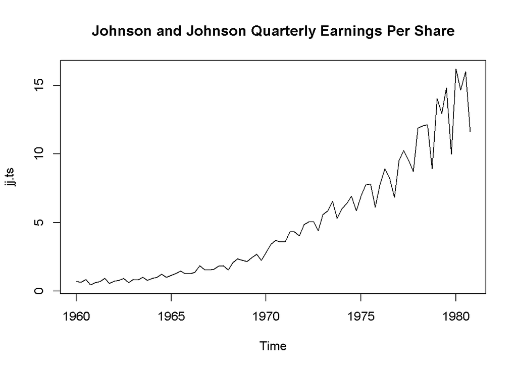

```r
jj.ts=as.ts(jj)

plot(jj.ts, main="Johnson and Johnson Quarterly Earnings Per Share")
```

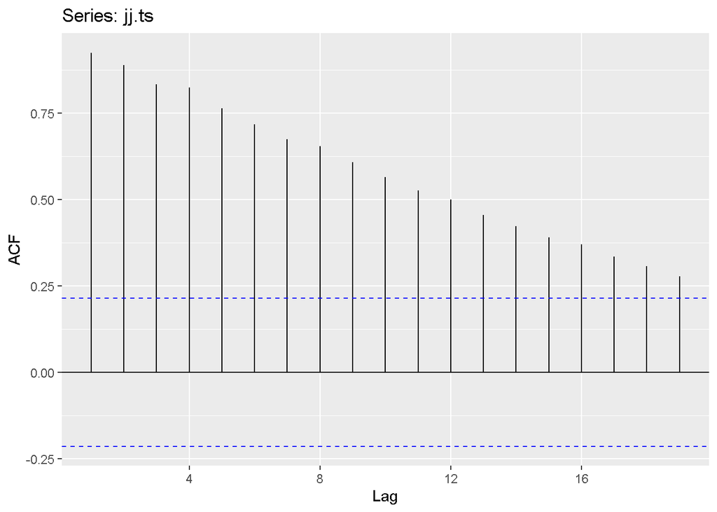

```r
ggAcf(jj.ts)
```

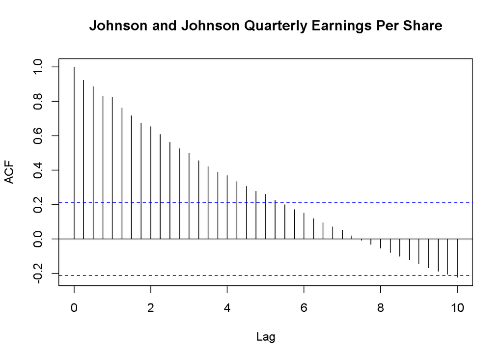

```r
acf(jj.ts, main="Johnson and Johnson Quarterly Earnings Per Share", lag=40)
```

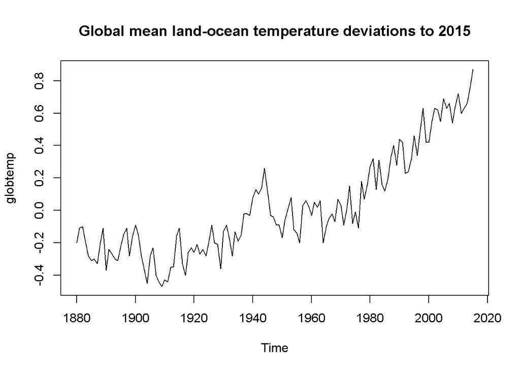

```r
plot(globtemp, main="Global mean land-ocean temperature deviations to 2015")
```

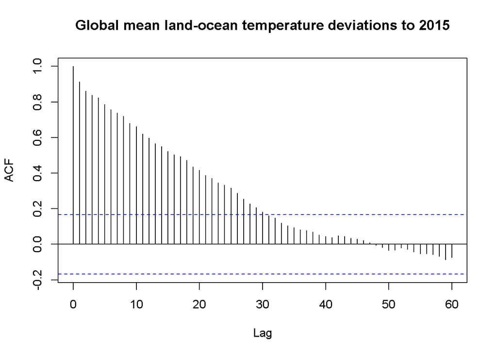

```r
acf(globtemp, 60, main="Global mean land-ocean temperature deviations to 2015")
```

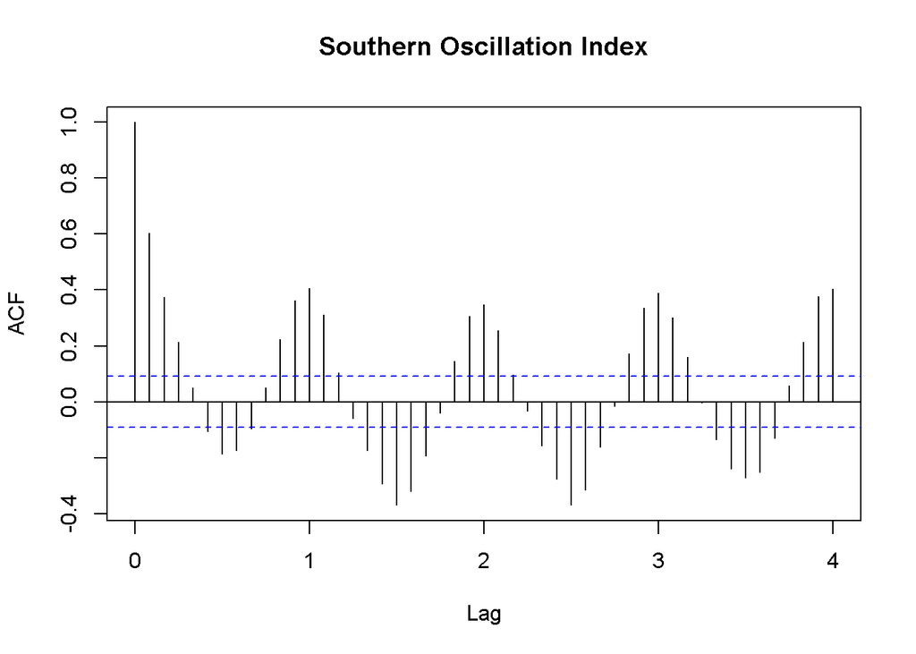

```r
acf(soi, 48, main="Southern Oscillation Index")
```

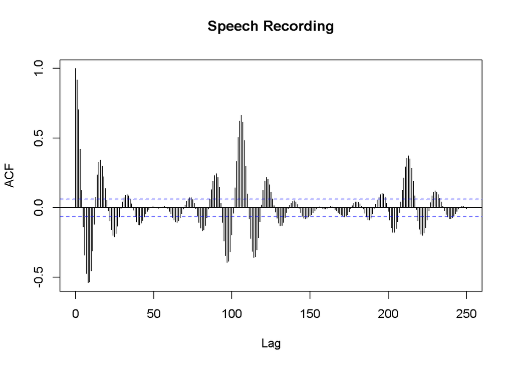

```r
acf(speech, 250, main="Speech Recording")
```

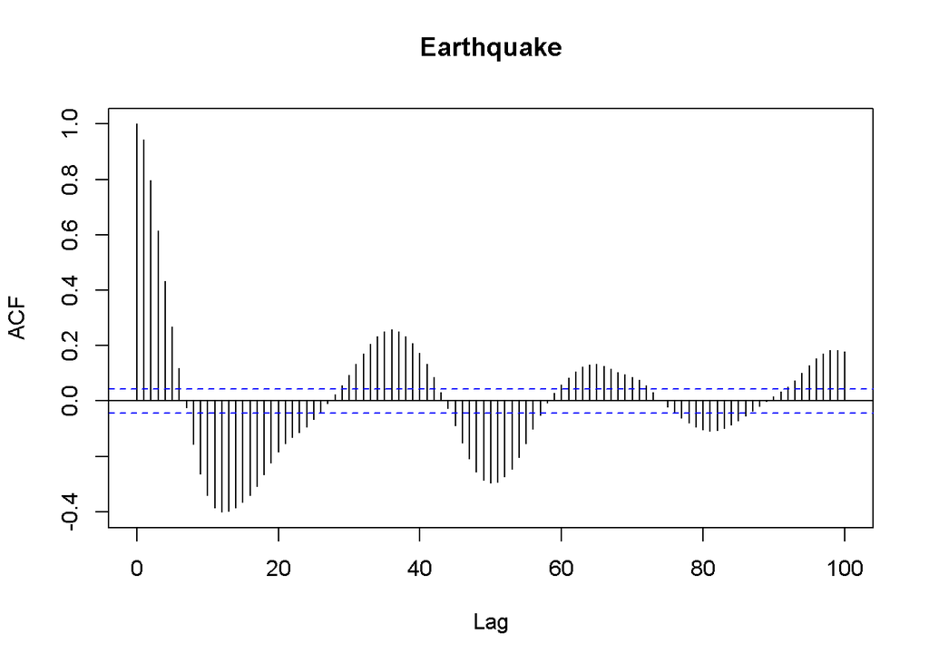

```r
acf(EQ5,100, main="Earthquake")
```

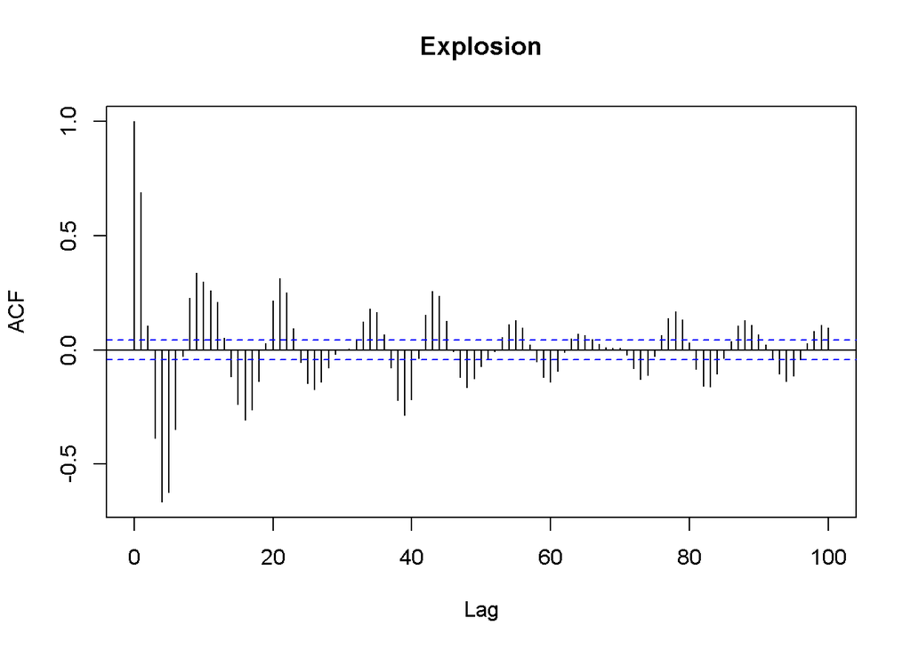

```r
acf(EXP6,100, main="Explosion")
```

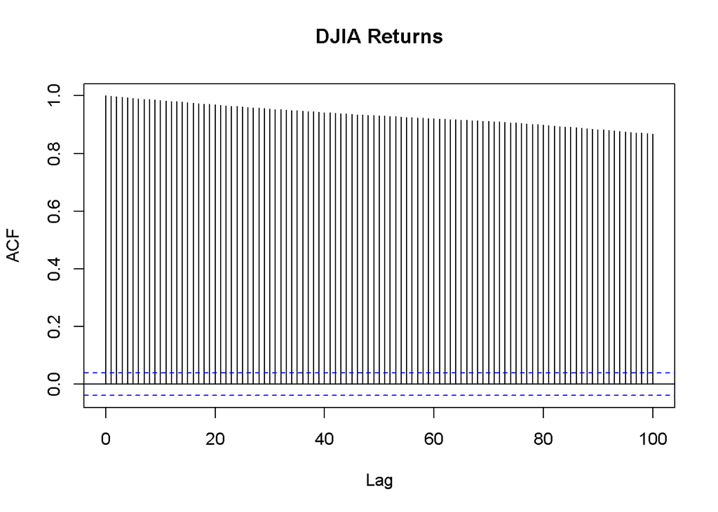

```r
dj=(djia$Close)[-1]
acf(dj, 100, main="DJIA Returns")
```

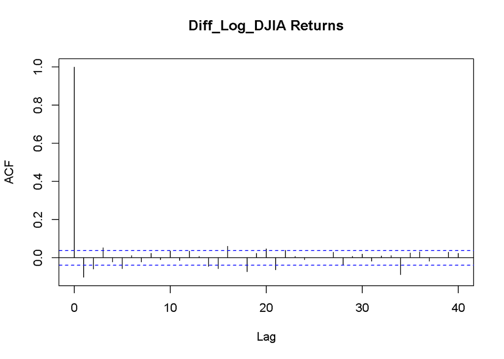

```r
djiar = diff(log(djia$Close))[-1]
acf(djiar, 40, main="Diff_Log_DJIA Returns")
```

## Random Walk

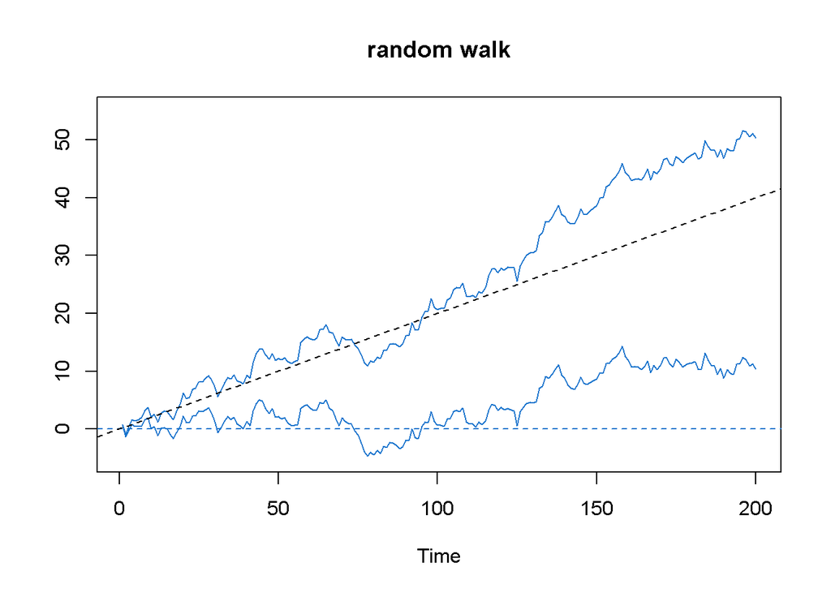

```r
set.seed(154) # so you can reproduce the results
w = rnorm(200); x = cumsum(w) # two commands in one line
wd = w +.2; xd = cumsum(wd)
plot.ts(xd, ylim=c(-5,55), main="random walk", ylab='',col=4)
lines(x, col=4); abline(h=0, col=4, lty=2); abline(a=0, b=.2, lty=2)
```

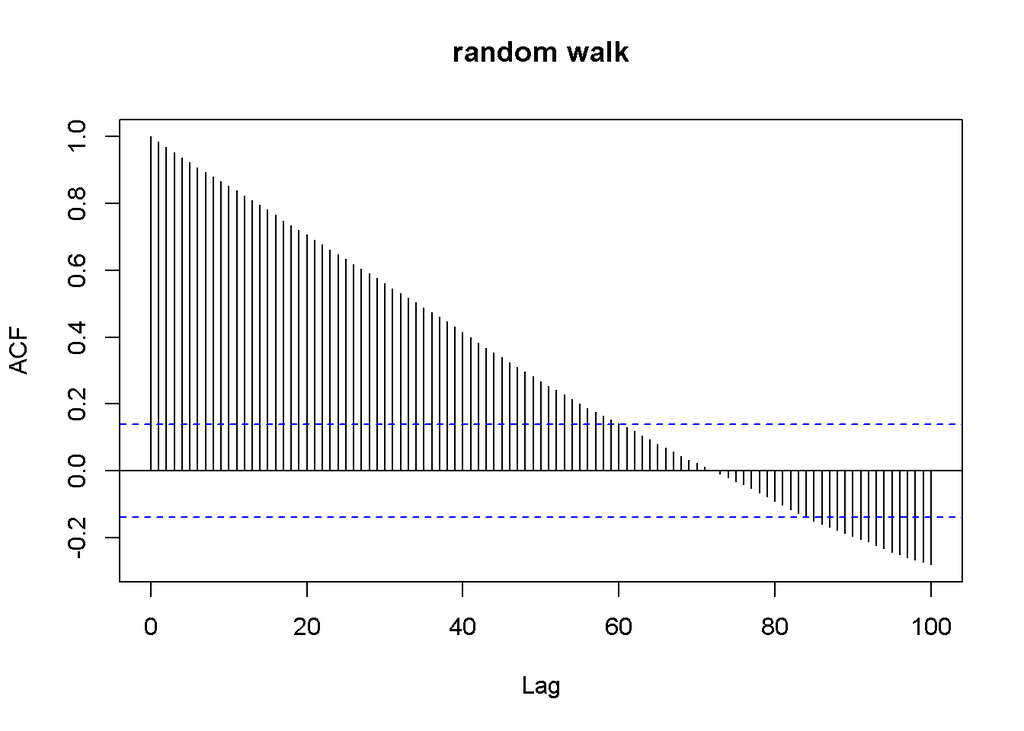

```r
acf(xd,100,main="random walk")
```

### Example

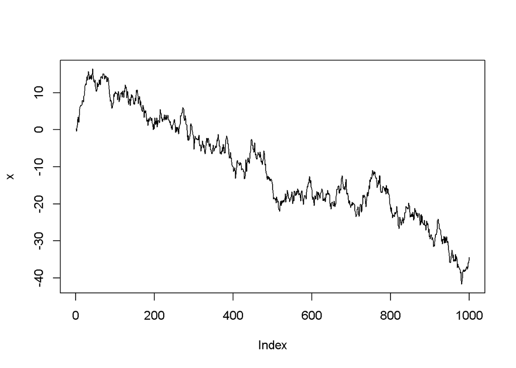

```r
set.seed(4)
x <- w <- rnorm(1000)
for (t in 2:1000) x[t] <- x[t-1] + w[t]
plot(x, type="l")
```

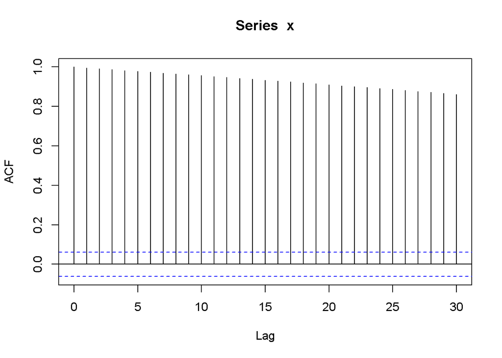

```r
acf(x)
```

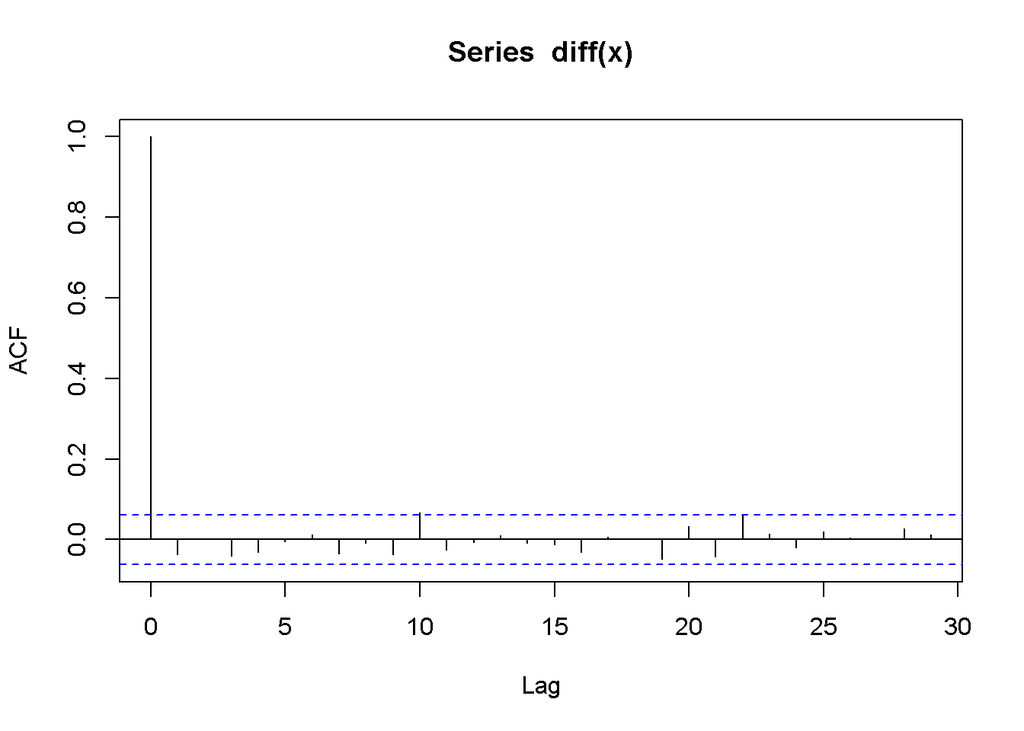

```r
acf(diff(x))
```

```r
#install.packages('quantmod')
```

This will create an object called MSFT (case sensitive!) into the R namespace, which contains the pricing and volume history of MSFT. We’re interested in the corporate-action adjusted closing price. We can use the following commands to (respectively) obtain the Open, High, Low, Close, Volume and Adjusted Close prices for the Microsoft stock: Op(MSFT), Hi(MSFT), Lo(MSFT), Cl(MSFT), Vo(MSFT), Ad(MSFT).

```r
library('quantmod')
getSymbols('MSFT', src='yahoo')
```

[output not shown]

```
## [1] "MSFT"
```

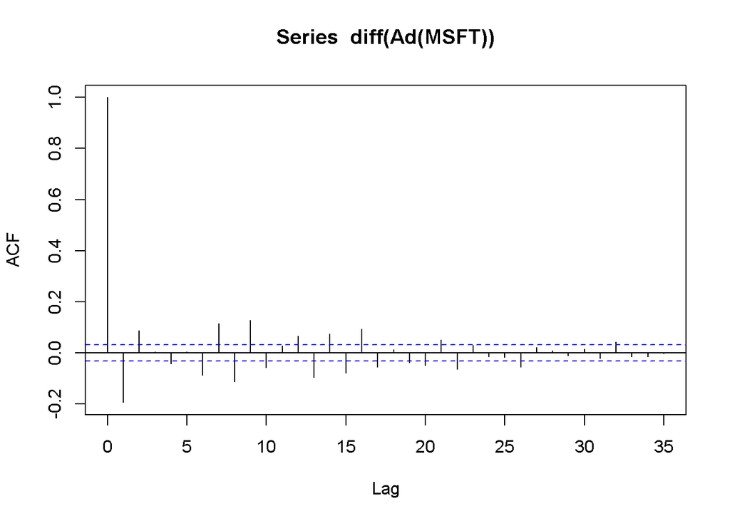

```r
#MSFT
acf(diff(Ad(MSFT)), na.action = na.omit)
```

```r
#getSymbols('^GSPC', src='yahoo')
#acf(diff(Ad(GSPC)), na.action = na.omit)
```

## Regression

```r
fit = lm(chicken~time(chicken), na.action=NULL)
# regress chicken on time
#time creates the vector of times at which a time series was sampled.
```

### Detrending Vs. Differencing

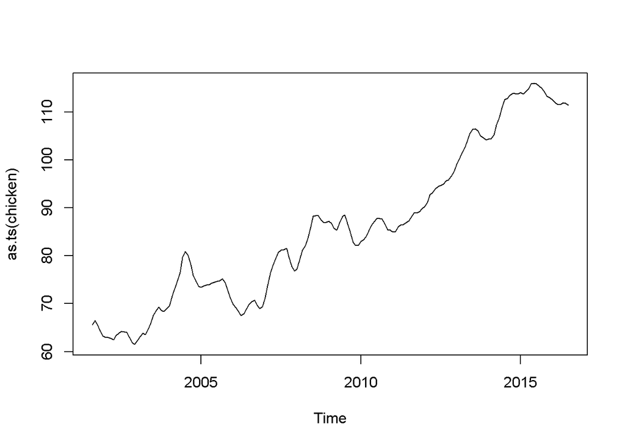

```r
data("chicken")
plot(as.ts(chicken))
```

```r
summary(fit <- lm(chicken~time(chicken), na.action=NULL))
```

```
##
## Call:
## lm(formula = chicken ~ time(chicken), na.action = NULL)
##
## Residuals:
##     Min      1Q  Median      3Q     Max
## -8.7411 -3.4730  0.8251  2.7738 11.5804
##
## Coefficients:
##                 Estimate Std. Error t value Pr(>|t|)
## (Intercept)   -7.131e+03  1.624e+02  -43.91   <2e-16 ***
## time(chicken)  3.592e+00  8.084e-02   44.43   <2e-16 ***
## ---
## Signif. codes:  0 '***' 0.001 '**' 0.01 '*' 0.05 '.' 0.1 ' ' 1
##
## Residual standard error: 4.696 on 178 degrees of freedom
## Multiple R-squared:  0.9173, Adjusted R-squared:  0.9168
## F-statistic:  1974 on 1 and 178 DF,  p-value: < 2.2e-16
```

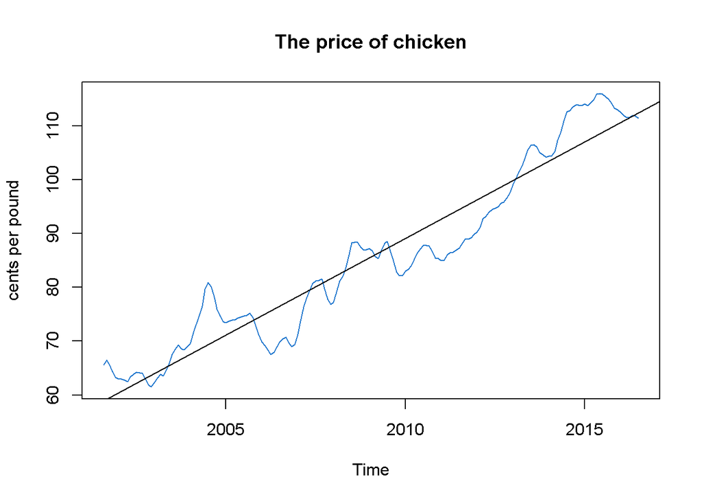

```r
plot(chicken, ylab="cents per pound",col=4, main="The price of chicken")
abline(fit) # add the fitted line
```

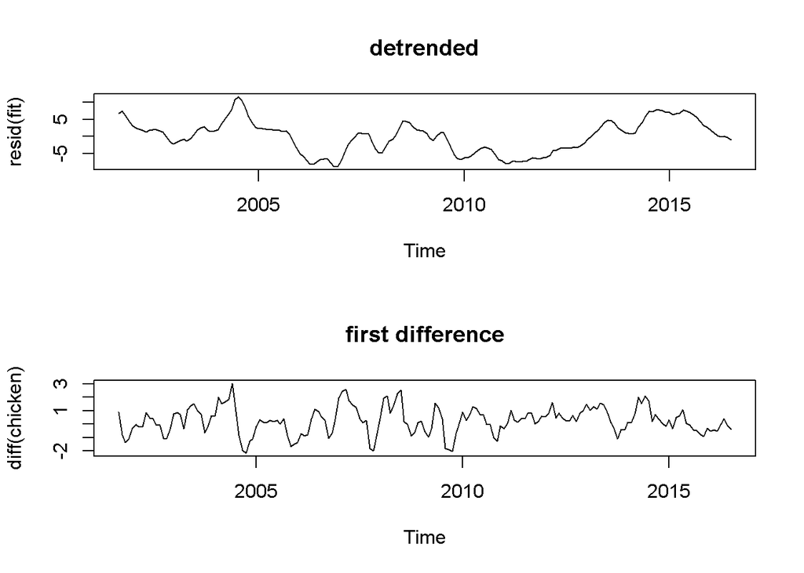

```r
par(mfrow=c(2,1))
plot(resid(fit), main="detrended")
plot(diff(chicken), main="first difference")
```

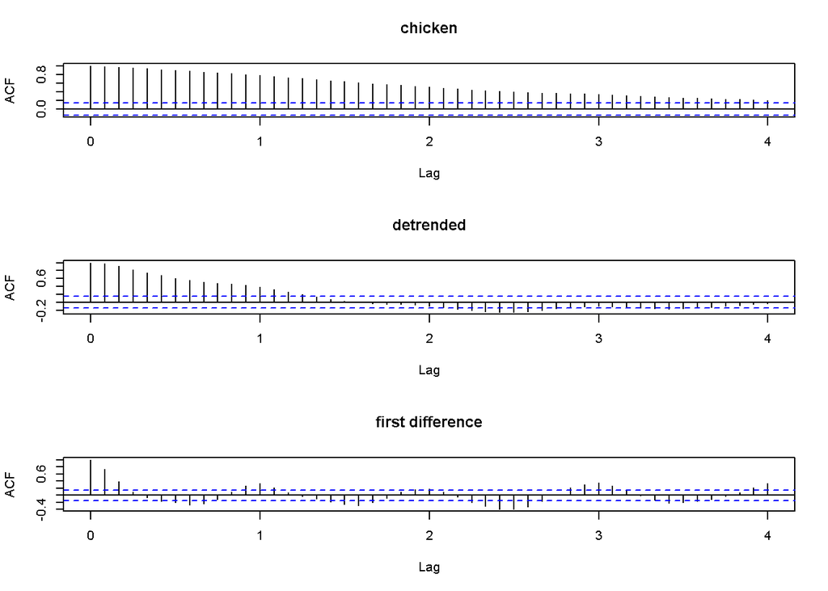

```r
par(mfrow=c(3,1)) # plot ACFs
acf(chicken, 48, main="chicken")
acf(resid(fit), 48, main="detrended")
acf(diff(chicken), 48, main="first difference")
```

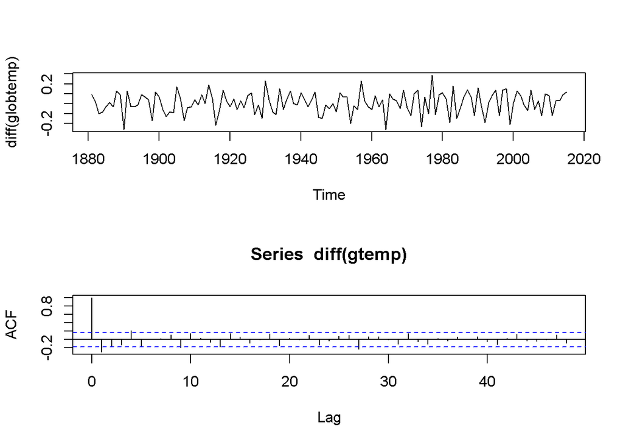

```r
par(mfrow=c(2,1))

plot(diff(globtemp))
acf(diff(gtemp), 48)
```

```r
mean(diff(globtemp)) # drift estimate = .008
```

```
## [1] 0.007925926
```

```r
xt=(globtemp)
xt1=lag(xt, k=1)
diff=xt-xt1
```

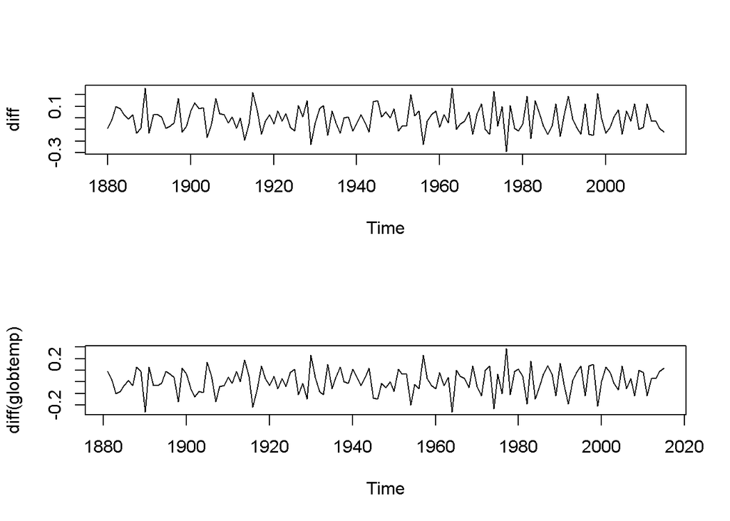

```r
par(mfrow=c(2,1))
plot(diff)
plot(diff(globtemp))
```

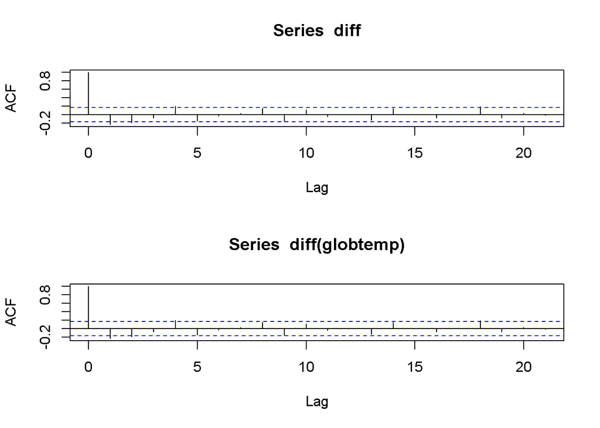

```r
par(mfrow=c(2,1))
acf(diff)
acf(diff(globtemp))
```

```r
# These are the same
df2=diff(x, differences = 2) #differencing twice
df22=diff(diff(x))
```

## AR Model

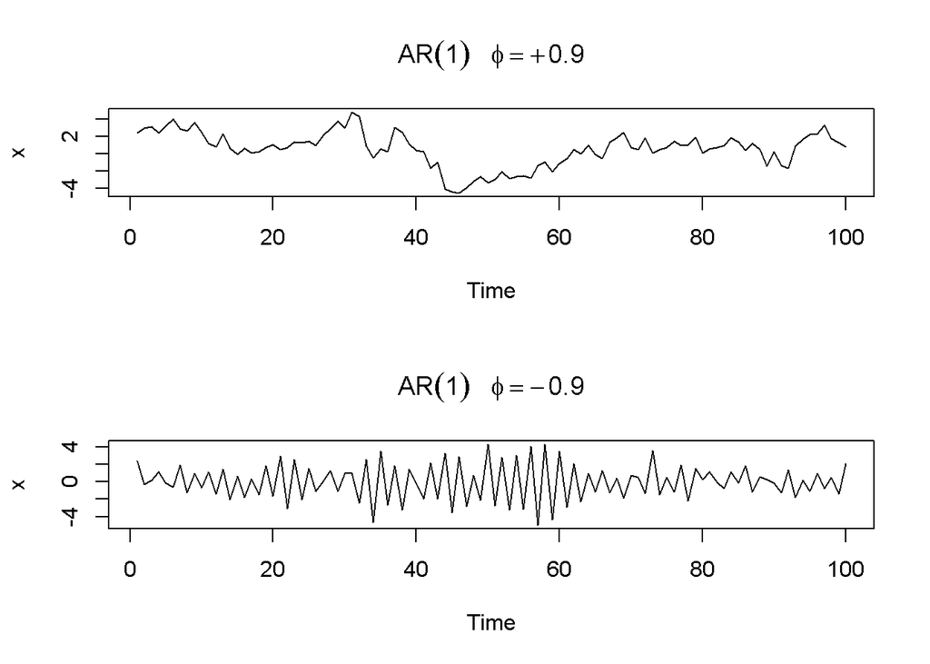

```r
par(mfrow=c(2,1))

plot(arima.sim(list(order=c(1,0,0), ar=.9), n=100), ylab="x",main=(expression(AR(1)~~~phi==+.9)))

plot(arima.sim(list(order=c(1,0,0), ar=-.9), n=100), ylab="x",main=(expression(AR(1)~~~phi==-.9)))
```

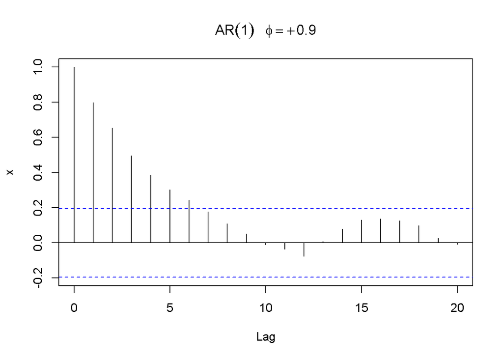

```r
acf(arima.sim(list(order=c(1,0,0), ar=.9), n=100), ylab="x",
     main=(expression(AR(1)~~~phi==+.9)))
```

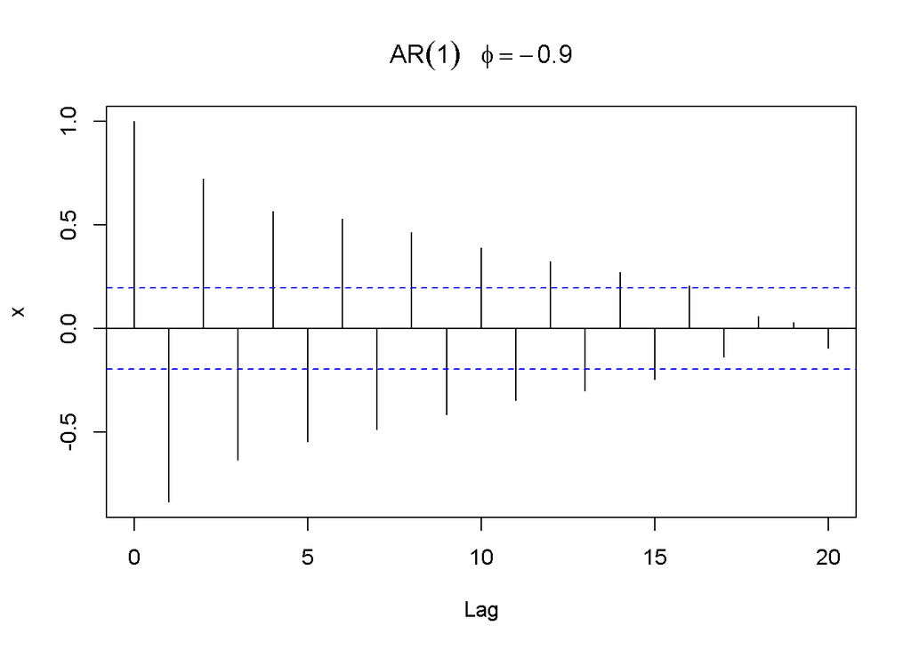

```r
acf(arima.sim(list(order=c(1,0,0), ar=-.9), n=100), ylab="x",
     main=(expression(AR(1)~~~phi==-.9)))
```

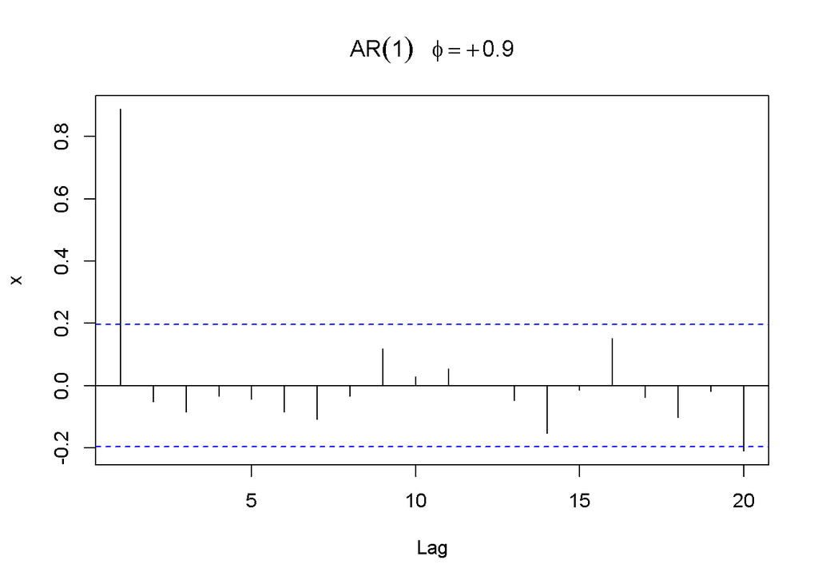

```r
pacf(arima.sim(list(order=c(1,0,0), ar=.9), n=100), ylab="x",
    main=(expression(AR(1)~~~phi==+.9)))
```

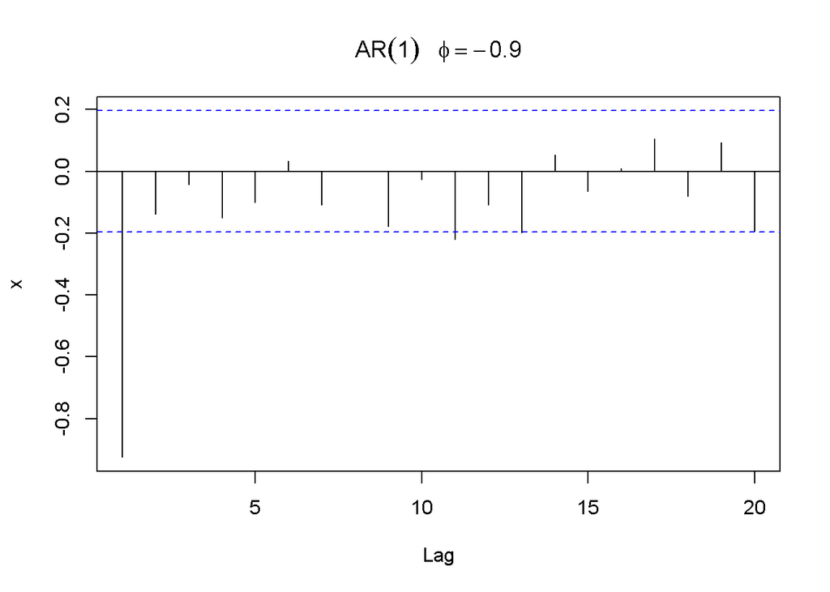

```r
pacf(arima.sim(list(order=c(1,0,0), ar=-.9), n=100), ylab="x",
    main=(expression(AR(1)~~~phi==-.9)))
```

```r
set.seed(132)
xt=arima.sim(list(order=c(1,0,0), ar=.9), n=1000)
auto.arima(xt)
```

```
## Series: xt
## ARIMA(1,0,0) with zero mean
##
## Coefficients:
##          ar1
##       0.8965
## s.e.  0.0139
##
## sigma^2 = 0.9902:  log likelihood = -1414.32
## AIC=2832.65   AICc=2832.66   BIC=2842.46
```

### Example 2: Autoregression

Autoregression is a time series model that uses observations from previous time steps as input to a regression equation to predict the value at the next time step.

It is a very simple idea that can result in accurate forecasts on a range of time series problems.

Suppose we consider the white noise series $w_t$ (above mentioned) as input and calculate the output using the second-order equation

$$x_t = x_{t-1}-0.9x_{t-2}+w_t$$

successively for $t = 1,2,...,500$. Above equation represents a regression or prediction of the current value $x_t$ of a time series as a function of the past two values of the series, and, hence, the term autoregression is suggested for this model.

One way to simulate and plot data from the model in R is to use the following commands (another way is to use arima.sim).

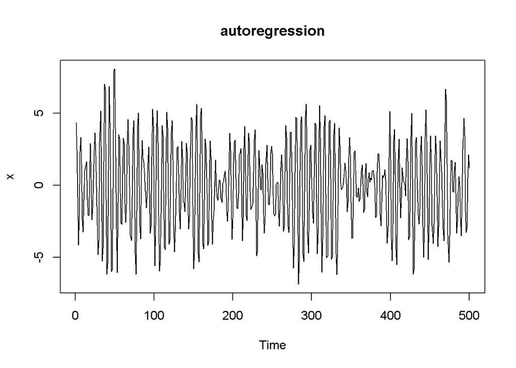

```r
w = rnorm(550,0,1) # 50 extra to avoid startup problems
x = filter(w, filter=c(1,-.9), method="recursive")[-(1:50)]
#If "convolution" a moving average is used:
#and if "recursive" an autoregression is used.#
plot.ts(x, main="autoregression")
```

or we can use arima.sim:

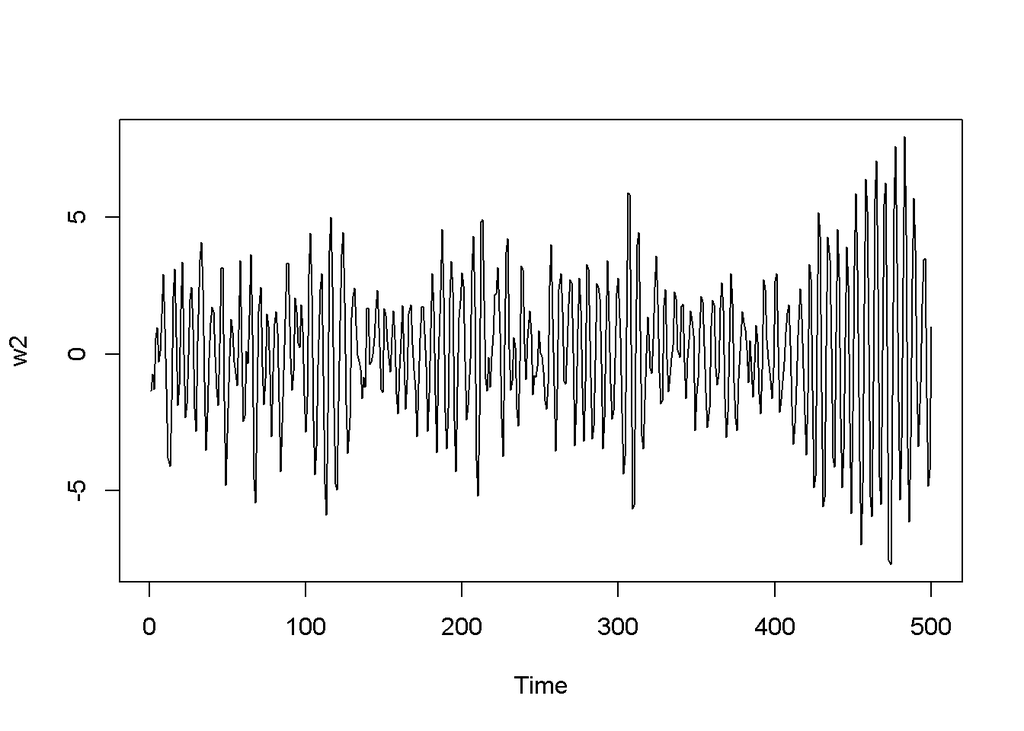

```r
w2 = arima.sim(model = list(order=c(2,0,0), ar=c(1,-0.9)) , n=500)
plot(w2)
```

```r
AR2 <- arima.sim(n = 500, model = list(ar = c(0.9, -0.6)), sd = 1)
```